# Project BOSTON

YU SUN & LIYU QIANG

2/24/2019

# first project

# Boston Crime

# Goals

# 1. summary each year total crime number,total crime number in each district and find top 3 dangerous district in Boston.

# 2.Seperate 24 hours to three 8-hours periods, 8am-16pm, 17pm-24am, 1am-7am. Compare the crime number happening in each periods in top 3 dangerous districts with the crime number distribution in Boston

# 3.Compared the crime group happening in each period in Boston and top 3 dangerous districts

```r
crime<-read.csv("/Users/sunyu/Desktop/IE 6600/bostoncrime.csv",sep = ",",stringsAsFactors = FALSE)
library(ggplot2)
library(dplyr)
year_crime<-summarise(group_by(crime,year),total_number_of_crime_each_year=n())
year_crime
```

| year | total_number_of_crime_each_year |
| --- | --- |
| 2015 | 53585 |
| 2016 | 99341 |
| 2017 | 101189 |
| 2018 | 98126 |
| 2019 | 12336 |

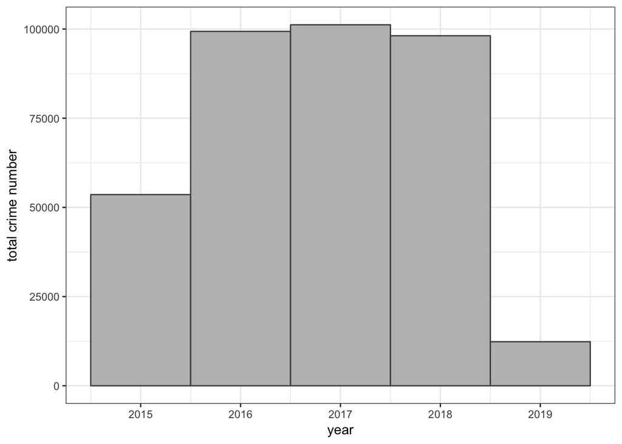

```r
ggplot(crime, aes(x = year)) +geom_histogram(binwidth = 1, color = "grey30", fill = "grey")+theme_bw()+ylab("total crime number")
```

```r
any(crime$district=="")
```

```
## [1] TRUE
```

```r
crime_district<-filter(crime, district != "")
district<-summarise(group_by(crime_district,district),total_number_of_crime=n())
district
```

| district | total_number_of_crime |
| --- | --- |
| A1 | 41057 |
| A15 | 7467 |
| A7 | 14861 |
| B2 | 57273 |
| B3 | 41196 |
| C11 | 48960 |
| C6 | 26641 |
| D14 | 22945 |
| D4 | 47461 |
| E13 | 19923 |

[output cut: 2 more lines]

```r
top_district_total<-arrange(district,desc(total_number_of_crime))[1:3,]
top_district_total
```

| district | total_number_of_crime |
| --- | --- |
| B2 | 57273 |
| C11 | 48960 |
| D4 | 47461 |

```r
top_district_total$district
```

```
## [1] "B2"  "C11" "D4"
```

```r
library(magrittr)
district_year<-crime_district %>%
  group_by(year,district)%>%
  summarise(total_crime=n()) %>%
  arrange(year,desc(total_crime)) %>%
  mutate(rank=row_number())
district_year
```

| year | district | total_crime | rank |
| --- | --- | --- | --- |
| 2015 | B2 | 8736 | 1 |
| 2015 | C11 | 7353 | 2 |
| 2015 | D4 | 7289 | 3 |
| 2015 | A1 | 6030 | 4 |
| 2015 | B3 | 5642 | 5 |
| 2015 | C6 | 3951 | 6 |
| 2015 | D14 | 3280 | 7 |
| 2015 | E13 | 2822 | 8 |
| 2015 | E18 | 2741 | 9 |
| 2015 | A7 | 2422 | 10 |

[output cut: 50 more lines]

```r
top3<-filter(district_year, rank <=3)
top3
```

| year | district | total_crime | rank |
| --- | --- | --- | --- |
| 2015 | B2 | 8736 | 1 |
| 2015 | C11 | 7353 | 2 |
| 2015 | D4 | 7289 | 3 |
| 2016 | B2 | 15804 | 1 |
| 2016 | C11 | 13689 | 2 |
| 2016 | D4 | 13063 | 3 |
| 2017 | B2 | 15772 | 1 |
| 2017 | C11 | 13601 | 2 |
| 2017 | D4 | 12916 | 3 |
| 2018 | B2 | 14990 | 1 |

[output cut: 5 more lines]